# 1_HR_PrvaLabVjezba_OI

**Obrada informacija**: Prva laboratorijska vježba

Unutar komprimiranog direktorija u kojem se nalazi ova bilježnica, nalazi se i .mat datoteka s podacima o vodostaju rijeke Save u periodu od 1.1.1982. do 31.12.2007. Svaki podatak označava jedan dan mjerenja vodostaja.

Vježba se izvodi u Pythonu/Google Colabu, a sve naredbe potrebne za provedbu vježbe te njihova objašnjenja dana su u predavanju. Ova laboratorijska vježba nosi 3 boda.

Kad ste gotovi s vježbom, na *Moodle* postavite .pdf izvješće s vježbe (.pdf izvješće možete generirati s naredbom File-Print-Location: PDF).

**1.** Učitajte biblioteke: NumPy, matplotlib.pyplot, scipy.fft, signal iz scipy te pywt.

```python
import numpy as np
import matplotlib.pyplot as plt
from scipy.fft import fft, fftfreq
from scipy import signal
import pywt
import matplotlib.dates as mdates
```

**2.** Učitajte podatke o vodostaju iz .mat datoteke koja se nalazi unutar istog komprimiranog direktorija. Učitani podaci su spremljeni u rječnik. Izdvojite ključ i pripadne podatke o vodostajima te po potrebi smanjite dimenziju.

Savjet: .mat datoteku učitajte sa svog Google Drivea (unutar mape Colab Notebooks na svom Google Driveu postavite .mat datoteku). Ostali savjeti nalaze se u sljedećem programskom odsječku.

```python
from scipy import io
kobas_iz_matlaba=io.loadmat("3_OIkobas.mat")
kobas = kobas_iz_matlaba['kobas'].flatten()
print(kobas_iz_matlaba)
```

```
{'__header__': b'MATLAB 5.0 MAT-file, Platform: MACI64, Created on: Sat Oct 10 13:46:29 2020', '__version__': '1.0', '__globals__': [], 'kobas': array([[661],
       [674],
       [685],
       ...,
       [242],
       [230],
       [228]], dtype=uint16)}
```

**3.** Ispišite: broj dana za koje postoje podaci o vodostajima, srednju vrijednost vodostaja, standardnu devijaciju, minimalnu vrijednost, maksimalnu vrijednost te median.

```python
broj_dana = kobas.size # kobas je tipa numpy.ndarray
print(f"Broj dana: {broj_dana}")

srednja_vrijednost_vodostaja = kobas.mean()
print(f"Srednja vrijednost vodostaja: {srednja_vrijednost_vodostaja}")

std_vodostaja = kobas.std()
print(f"Standardna devijacija vodostaja: {std_vodostaja}")

min_vodostaja = kobas.min()
print(f"Minimalna vrijednost vodostaja: {min_vodostaja}")

max_vodostaja = kobas.max()
print(f"Maksimalna vrijednost vodostaja: {max_vodostaja}")

medijan_vodostaja = np.median(kobas)
print(f"Medijan vodostaja: {medijan_vodostaja}")
```

```
Broj dana: 9496
Srednja vrijednost vodostaja: 294.25758213984835
Standardna devijacija vodostaja: 183.09167165945507
Minimalna vrijednost vodostaja: 17
Maksimalna vrijednost vodostaja: 878
Medijan vodostaja: 255.0
```

**4.** Nacrtajte vodostaj. Obilježite x i y os te naslov slike.

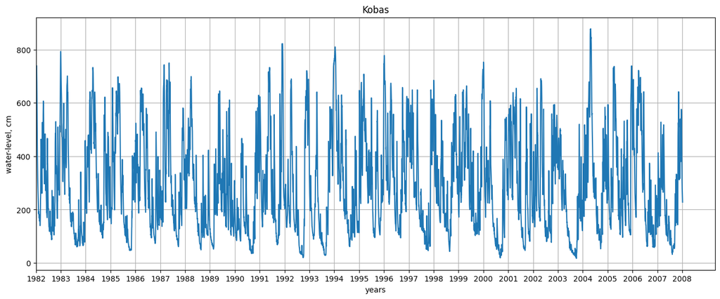

```python
end_datum = '2008-10-10'
start_datum = np.datetime64(end_datum) - np.timedelta64(broj_dana, 'D')

datumi = np.arange(start_datum, np.datetime64(end_datum), dtype='datetime64[D]')

plt.figure(figsize=(16,6))
plt.plot(datumi, kobas)
plt.xlabel('years')
plt.ylabel('water-level, cm')
plt.title('Kobas')
plt.grid(True)

plt.xlim(start_datum)

ax = plt.gca()
plt.xticks([start_datum + np.timedelta64(i) for i in range(0, broj_dana, 365)])
ax.xaxis.set_major_formatter(mdates.DateFormatter('%Y'))

plt.show()
```

**5.** Izračunajte diskretnu Fourierovu transformaciju zadanog vodostaja. Ispišite dobivene vrijednosti. Nacrtajte apsolutnu vrijednost dobivenih koeficijenata.

```
[2794270.            -0.j           -9312.52756202+49784.33987081j
   80617.82235263-75905.53826228j ...  -75144.8689581 -18406.78122837j
   80617.82235263+75905.53826228j   -9312.52756202-49784.33987081j]
```

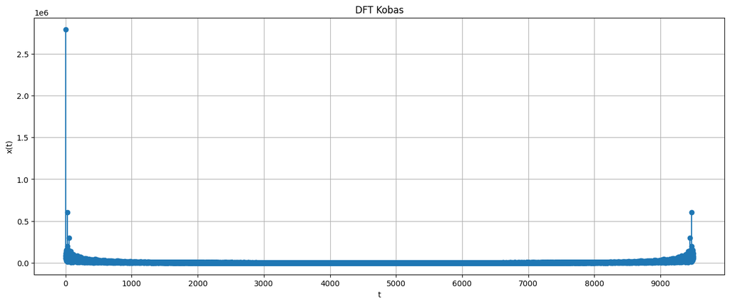

```python
transform = fft(kobas)
n = len(transform)
vrijeme = np.arange(n)

print(transform)
abs_transform = np.abs(transform)

plt.figure(figsize=(16,6))
plt.stem(vrijeme, abs_transform, basefmt=" ")
plt.xticks(np.arange(0,n,1000))
plt.xlabel('t')
plt.ylabel('x(t)')
plt.title('DFT Kobas')
plt.grid(True)
plt.show()
```

**6.** Izračunajte Fourierovu transformaciju na vremenskom otvoru zadanog vodostaja koristeći pravokutni otvor širine 2 godine. Prikažite rezultat pomoću pcolormesh. Odgovorite: koje frekvencije su vidljive u vodostaju? Koje godine se javljaju?

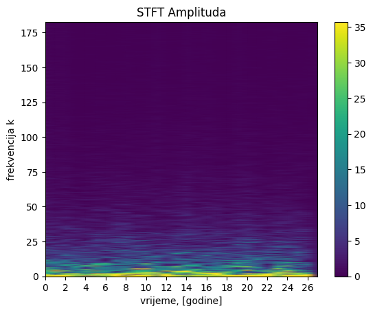

```python
window = signal.windows.boxcar(365*2)
fs = 365
f, t, Zxx  = signal.stft(kobas, fs, window, nperseg=365*2)

plt.pcolormesh(t, f, np.abs(Zxx), vmin=0,vmax=np.abs(Zxx.max())/10, shading='gouraud')
plt.colorbar()
plt.title("STFT Amplituda")
plt.ylabel("frekvencija k")
plt.xlabel("vrijeme, [godine]")
plt.xticks(np.arange(0,len(t),2))
plt.show()
```

Fourierova transformacija na otvoru širine 2 godine:

Žuta boja predstavlja višu amplitudu (tj. vodostaj)

Svake dvije godine amplituda pada i raste (s žute boje pređe na zelenkastu pa natrag), također ovisi o godišnjem dobu koje se mijenja svaka 3 mjeseca zbog čega je visoka amplituda prisutna tokom cijelog promatranja -> varijacija u amplitudi se pojavljuje na dužem periodu

**7.** Upotrijebite drugu širinu otvora (po izboru) i ponovite prethodni zadatak. Ispišite koju širinu ste upotrijebili. Objasnite razlike u dobivenim slikama.

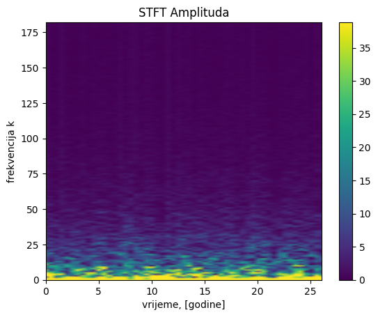

```
Širina otvora je 365 dana
```

```python
nperseg = 365
window = signal.windows.boxcar(nperseg)
fs = 365
f, t, Zxx  = signal.stft(kobas, fs, window, nperseg)

plt.pcolormesh(t, f, np.abs(Zxx), vmin=0,vmax=np.abs(Zxx.max())/10, shading='gouraud')
plt.colorbar()
plt.title("STFT Amplituda")
plt.ylabel("frekvencija k")
plt.xlabel("vrijeme, [godine]")
plt.show()

print(f"Širina otvora je {nperseg} dana")
```

Fourierova transformacija na otvoru širine 1 godine:

Vremenska razlučivost je bolja, promjene u amplitudi su preciznije i koncentrirane u kraćim vremenskim periodima

Frekvencijski spektar je manje precizan, niske frekvencije su manje oštre nego u vremenskom otvoru od 2 godine

**8.** Ispišite sve obitelji kontinuiranih valića koje se nalaze u PyWavelets biblioteci. Na istoj slici, koristeći subplot naredbu, nacrtajte dvije valićne funkcije po izboru. U naslovu svake slike napišite o kojim valićima se radi.

```
['cgau1', 'cgau2', 'cgau3', 'cgau4', 'cgau5', 'cgau6', 'cgau7', 'cgau8', 'cmor', 'fbsp', 'gaus1', 'gaus2', 'gaus3', 'gaus4', 'gaus5', 'gaus6', 'gaus7', 'gaus8', 'mexh', 'morl', 'shan']
```

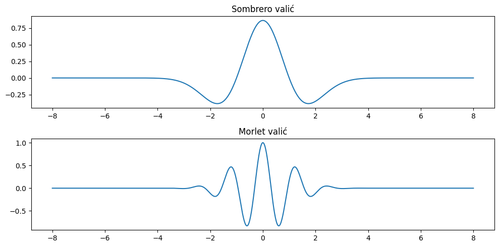

```python
print(pywt.wavelist(kind="continuous"))

wave1 = 'mexh'
wave2 = 'morl'

w1 = pywt.ContinuousWavelet(wave1)
w2 = pywt.ContinuousWavelet(wave2)

psi1, t1 = w1.wavefun(level=10)
psi2, t2 = w2.wavefun(level=10)

plt.figure(figsize=(10,5))
plt.subplot(2,1,1)
plt.plot(t1, psi1)
plt.title("Sombrero valić")

plt.subplot(2,1,2)
plt.plot(t2, psi2)
plt.title("Morlet valić")

plt.tight_layout()
plt.show()
```

**9.** Koristeći Morlet valić, odredite kontinuiranu valićnu transformaciju zadanog vodostaja. Nacrtajte apsolutnu vrijednost dobivenih koeficijenata. Odgovorite: koje frekvencije su vidljive u vodostaju? Koje godine se javljaju?

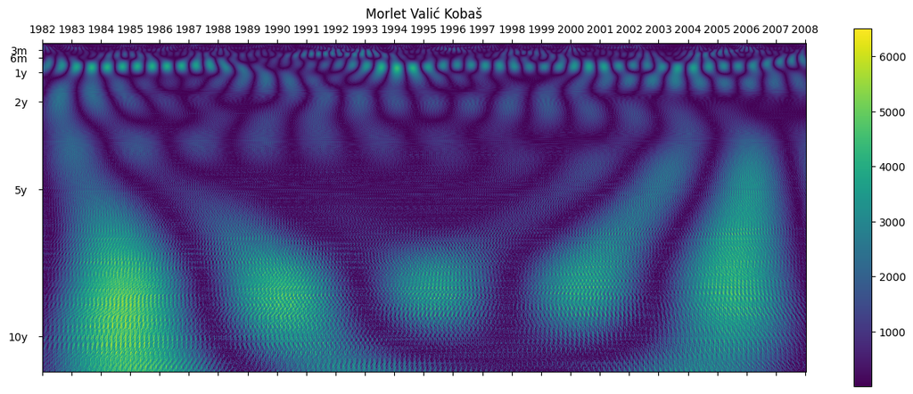

```python
scale = np.arange(1, 4096) # ako je skala potencija broja dva analiza je efikasnija i preciznija
coef, freqs = pywt.cwt(kobas, scale, wave2)

plt.figure(figsize=(16,6))
plt.matshow(np.abs(coef), fignum=1)
plt.colorbar()

plt.title("Morlet Valić Kobaš")

x_ticks = [day for day in range(n) if day%365 == 0]
x_labels = [1982 + i for i in range(len(x_ticks))]
plt.xticks(x_ticks, x_labels)

plt.tick_params(axis="y", pad=10)
plt.yticks([90, 365//2, 365, 365*2, 365*5, 365*10], ['3m', '6m', '1y', '2y', '5y', '10y'])
plt.show()
```

Plava boja između viših amplituda označuje periode gdje se vodostaj nije puno mijenjao i gdje nije bilo poplava ili drugih ekstremnih događaja

**10.** Odgovorite: objasnite razliku u dobivenim rezultatima STFT i CWT.

Valićna transformacija rezultira analizom signala u različitim frekvencijama po različitim rezolucijama skaliranjem što rezultira multirezolucijskim podatkom koji je striktno poboljšanje Fourierove analize nad konstantnim vremenskim okvirom.

Kod Fourierove analize nad vremenskim okvirom radimo trade-off između toga želimo li bolju vremensku rezoluciju (kraći vremenski period) ili bolju frekvencijsku rezoluciju (duži vremenski period), valićna transformacija je poboljšanje ove metode gdje funkcija nekog vala imitira vremenski okvir kod Fourierove analize.

Valovi se mogu skalirati : kratki valovi bolje razlučuju komponente s visokom frekvencijom uz dobru vremensku rezoluciju, duži valovi bolje razlučuju komponente s niskom frekvencijom uz lošu vremensku rezoluciju